# Reproducible Research: Peer Assessment 1 report

*The following report shows the analysis of personal movement activity patterns using an activity monitoring device. This device collected data at 5-minute intervals through out the day. The collected data inludes two months of measurements collected during October and November of 2012. It includes the number of steps taken in 5-minute intervals each day, along with the date of the measurement.*

*An analysis was carried out, exploring the total amount of steps per day, average number of steps, and differences between measurments collected during the week or at the weekends, among others.*

## Loading and preprocessing the data

For loading and processing of the data, one should setup the working directory for the R session in the same folder where the raw data is located.

After this the file is unzipped and read, using the following code:

```r
unzip("activity.zip")
#Reading of data
activity <- read.csv("activity.csv")
```

## What is mean total number of steps taken per day?

For answering this question three data are needed:

**1. Calculate the total number of steps taken per day**

To obtain the number of steps per day, the data must be aggregated, ie. sum, without having to deal with NA, using aggregate, by day

```r
StepsDay <- aggregate(steps ~ date, data = activity, FUN = sum, na.rm=TRUE)
```

After this aggregation the total number of steps taken by day are depicted here:

```r
StepsDay
```

```
         date steps
1  2012-10-02   126
2  2012-10-03 11352
3  2012-10-04 12116
4  2012-10-05 13294
5  2012-10-06 15420
6  2012-10-07 11015
7  2012-10-09 12811
8  2012-10-10  9900
9  2012-10-11 10304
10 2012-10-12 17382
11 2012-10-13 12426
12 2012-10-14 15098
13 2012-10-15 10139
14 2012-10-16 15084
```

[output cut: 39 more lines]

**2. Make a histogram of the total number of steps taken each day**

To see the distribution/frecuency of steps per day a histogram is plotted:

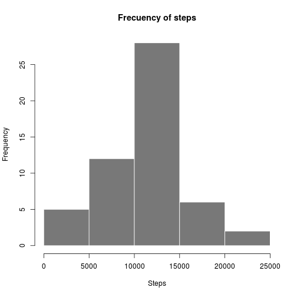

```r
hist(StepsDay$steps, xlab="Steps", main="Frecuency of steps", col="grey47", border="white")
```

**3. Calculate and report the mean and median of the total number of steps taken per day**

For this the mean and median are obtained:

**Mean:**

```r
mean(StepsDay$steps)
```

```
## [1] 10766.19
```

**Median:**

```r
median(StepsDay$steps)
```

```
## [1] 10765
```

## What is the average daily activity pattern?

In order to see how's the daily activity pattern, two steps are needed.

**1. A time series plot of the 5-minute interval and the average number of steps taken, averaged across all days.**

For this the first step is to aggregate the data by interval and calculate the mean of steps per interval.

```r
StepsInterval <- aggregate(steps ~ interval, data = activity, FUN = mean, na.rm=TRUE)
```

After this a time-series graph with the mean steps per interval can be made.

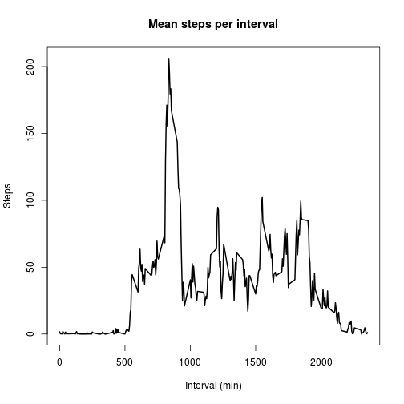

```r
plot(StepsInterval, type="l", xlab="Interval (min)", ylab="Steps", main="Mean steps per interval", lwd=2)
```

**2. Which 5-minute interval, on average across all the days in the dataset, contains the maximum number of steps?**

For this the maximum mean number of steps is found and the interval is reported.

```r
StepsInterval[StepsInterval$steps == max(StepsInterval$steps),]
```

```
##     interval    steps
## 104      835 206.1698
```

Being the interval **835** the one with highest number of steps.

## Imputing missing values

After a brief view of the original RAW data, it is noted that there are a some days/intervals in which there are missing values. This may be a source of bias in the calculations. To test for bias and to complement the report, the total number of NAs are to be reported and a strategy will be generated to impute the missing values with the mean of the corresponding 5-minute interval.

**1. Calculate and report the total number of missing values in the dataset.**

The total missing values, NAs are reported.

```r
sum(is.na(activity$steps))
```

```
## [1] 2304
```

There are **2304** missing values. No NAs are reported in the dates or intervals, as shown below:

```r
sum(is.na(activity$date))
```

```
## [1] 0
```

```r
sum(is.na(activity$interval))
```

```
## [1] 0
```

**2. Imputaton of missing values in the dataset.**

For this a replacement of the missing values with the average of each 5 minute interval was carried out, and a new dataset was created with the imputated values. Briefly, the code runs a loop in which it searches if there are missing values in each interval, if it founds one it then looks for the average steps in that interval, using the previous calculated data aggregation (StepsInterval), and replaces the NA with this value.

```r
nActivity <- activity
#Create function that goes through every line
for (i in 1:nrow(nActivity)) {
    #Look for NA
    if (is.na(nActivity$steps[i])) {
        #If found replace them with corresponding mean interval value
        nActivity$steps[i] <- StepsInterval$steps[which(nActivity$interval[i] == StepsInterval$interval)]
  }
}
```

Then it is assessed if there are missing values in the new dataset:

```r
sum(is.na(nActivity$steps))
```

```
## [1] 0
```

**3. Generate a histogram of the total number of steps taken each day.**

A histogram is created with the new dataset. For this as before, first the data is aggregated by day.

```r
StepsDayN <- aggregate(steps ~ date, data = nActivity, FUN = sum, na.rm=TRUE)
```

And then the histogram of steps per day is generated.

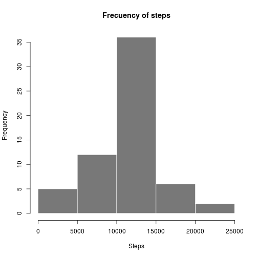

```r
hist(StepsDayN$steps, xlab="Steps", main="Frecuency of steps", col="grey47", border="white")
```

**4. Calculate and report the mean and median total number of steps taken per day.**

For this the mean and median are obtained:

**Mean:**

```r
mean(StepsDayN$steps)
```

```
## [1] 10766.19
```

**Median:**

```r
median(StepsDayN$steps)
```

```
## [1] 10766.19
```

**5. Do these values differ from the estimates from the first part of the assignment? What is the impact of imputing missing data on the estimates of the total daily number of steps?**

After calculating the mean and median, there does not seems to be a difference of the values, the means are equal ~10766 steps and the median is one step lower in the data with the missing values. Furthermore, by comparing the histograms it can also be seen that the data distributes in the same manner, only the data with the imputed values has a higher frecuency where the median/mean is located, thus avoiding any skewing of the data.

In summary, in this case the there was not a big impact by imputing the values, which maybe critical in other datasets.

## Are there differences in activity patterns between weekdays and weekends?

In order to see if there's a difference in the activity patterns depending if it is a weekday or during the weekend, the day of the week in which the measurments were done was obtained, and then compared between weekdays and weekend, using the dataset with imputed NAs.

**1. Create a new factor variable in the dataset with two levels – “weekday” and “weekend” indicating whether a given date is a weekday or weekend day.**

For this the data was first divided into week days and weekend

```r
nac <- nActivity
#Change class of dates
nac$Day <- weekdays(as.Date(nActivity$date))
#Replace days by weekday or weekend
nac$Day[nac$Day == "Monday"] <- "Weekday"
nac$Day[nac$Day == "Tuesday"] <- "Weekday"
nac$Day[nac$Day == "Wednesday"] <- "Weekday"
nac$Day[nac$Day == "Thursday"] <- "Weekday"
nac$Day[nac$Day == "Friday"] <- "Weekday"
nac$Day[nac$Day == "Saturday"] <- "Weekend"
nac$Day[nac$Day == "Sunday"] <- "Weekend"
```

Then the data is splitted between *weekday* or *weekend* and each one aggregated by interval

```r
InterWeek <- nac[which(nac$Day=="Weekday"),]
InterEnd <- nac[which(nac$Day=="Weekend"),]
#Then data is aggregated
InterWeek2 <- aggregate(steps ~ interval, data = InterWeek, FUN = mean, na.rm=TRUE)
InterEnd2 <- aggregate(steps ~ interval, data = InterEnd, FUN = mean, na.rm=TRUE)
#A tag is added to each dataset to know to which day it belongs
InterWeek2$Day <- "Weekday"
InterEnd2$Day <- "Weekend"
#Finally the data is re-grouped
medias <- rbind(InterWeek2, InterEnd2)
```

**2. Generate a panel plot containing a time series plot of the 5-minute interval and the average number of steps taken, averaged across all weekday days or weekend days.**

For this the data is grouped to be displayed by day of the week, either weekday or weekend, and a panel plot is created using ggplot2.

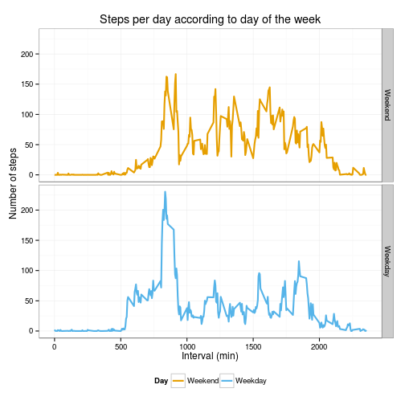

```r
library(ggplot2)
#Order the factors to display
day_order <- c("Weekend","Weekday")
medias$Day <- ordered(medias$Day, day_order)
#Ordering done
medias <- medias[with(medias, order(Day)),]
colors <- c("#E69F00", "#56B4E9")
ggplot(medias, aes(x=interval, y=steps, color=Day)) + facet_grid(Day ~ .) +
  geom_line(size=1) + scale_colour_manual(values=colors) +
  ylab(expression("Number of steps")) + xlab("Interval (min)") +
  ggtitle(expression("Steps per day according to day of the week")) + theme_bw() +
  theme(legend.position="bottom")
```

As seen by the plot, there seems to be a higher number of steps during early intervals during the week compared to the weekend. However, during the rest of the day there seems to be more activity in the intervals after the big peak of the weekday interval ~835 during the weekend. In summary, it seems to be the case that there are differences in the activity patterns between weekdays and weekends.